# Breast Cancer Analysis Using R - Machine Learning

# Introduction

According to a 2018 report by the World Health Organization, cancer is a leading cause of death worldwide, breast cancer is also the second most common cancer worldwide. So, we decided to study the breast cancer Wisconsin dataset, using different methods of classiﬁcation in ML and comparing them to determine the appropriate one. This analysis will be used to determine whether a certain tumor is benign or malignant. We have chosen R language for the implementation. Here's the dataset link https://www.kaggle.com/uciml/breast-cancer-wisconsin-data

# Why R?

R is an open source programming language used for statistical computations, data analysis and graphical representation of data. It is the best choice in our case as it has many packages useful for ML & statistical processes, also it has many advantages including data wrangling and data visualization.

# Machine Learning Model

## 1. Pre-Processing

The dataset we are working on consists of 569 examples and 32 features. To avoid irrelevant or redundant features that may have a negative effect on the accuracy of the classifier, we have used **feature selection** by ordering features by their importance, then we have neglected the least important ones.

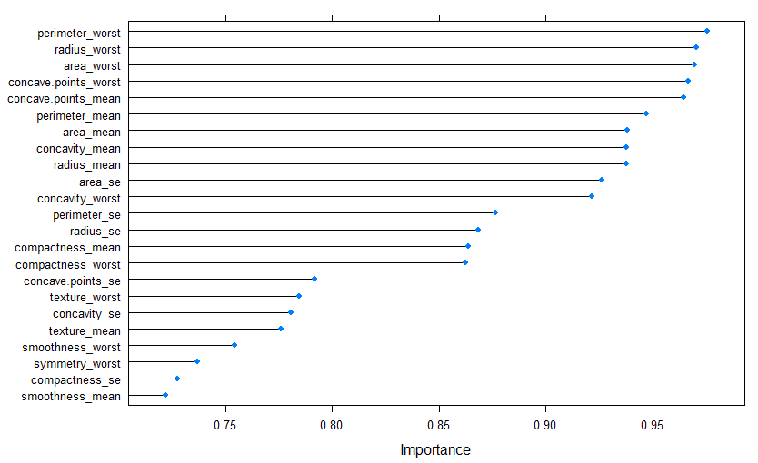

## 2. Classification Methods

In machine learning, classification is the process of identifying to which of a set of classes a new example belongs. There are several methods of classification but we have chosen the most appropriate ones to our dataset which are:

1. Decision Tree
2. Naive Bayes
3. KNN

### 2.1 Decision Tree

A Decision Tree is a supervised ML algorithm wherein each node represents a feature, the link between the nodes represents a decision and each leaf node represents an outcome. It's considered to be one of the most useful ML algorithms, also it is suitable for our dataset as it is used extensively for diagnosis of diseases such as breast cancer, ovarian cancer, heart sound diagnosis, etc.

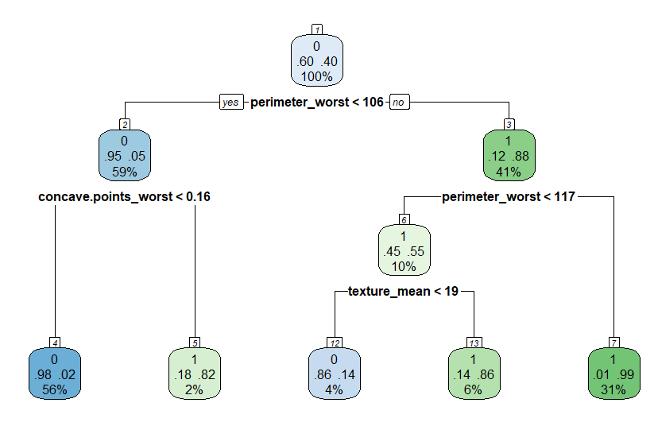

1. Accuracy = 92.1%
2. Sensitivity = 93.1%
3. Specificity = 90.68%